# Analytics Vidhya JOB-A-THON - May 2021

https://datahack.analyticsvidhya.com/contest/job-a-thon-2/

## Import Libraries

```python
import numpy as np
import pandas as pd
import matplotlib.pyplot as plt
import seaborn as sns

from scipy import stats
from sklearn.impute import KNNImputer
from sklearn.model_selection import train_test_split, GridSearchCV, cross_val_score
from sklearn.preprocessing import StandardScaler, MinMaxScaler
import sklearn.metrics as metrics
from sklearn.linear_model import LogisticRegression
from sklearn.ensemble import RandomForestClassifier, GradientBoostingClassifier
from xgboost import XGBClassifier
from lightgbm import LGBMClassifier
from catboost import CatBoostClassifier

sns.set(style='darkgrid')
# pd.options.display.max_rows=None
pd.options.mode.chained_assignment = None
```

## Read Train and Test Data

**Definition of all the variables in Train and Test Data:**

- ID → Unique Identifier for a row
- Gender → Gender of the Customer
- Age → Age of the Customer (in Years)
- Region_Code → Code of the Region for the customers
- Occupation → Occupation Type for the customer
- Channel_Code → Acquisition Channel Code for the Customer (Encoded)
- Vintage → Vintage for the Customer (Account Length) (In Months)
- Credit_Product → If the Customer has any active credit product (Home loan, Personal loan, Credit Card etc.)
- Avg_Account_Balance → Average Account Balance for the Customer in last 12 Months
- Is_Active → If the Customer is Active in last 3 Months
- Is_Lead(Target) → If the Customer is interested for the Credit Card
  - 0 : Customer is not interested
  - 1 : Customer is interested

```python
train_data = pd.read_csv('data/train_s3TEQDk.csv')
train_data = train_data.set_index('ID')
train_data.head()
```

| ID | Gender | Age | Region_Code | Occupation | Channel_Code | Vintage | Credit_Product | Avg_Account_Balance | Is_Active | Is_Lead |
| --- | --- | --- | --- | --- | --- | --- | --- | --- | --- | --- |
| NNVBBKZB | Female | 73 | RG268 | Other | X3 | 43 | No | 1045696 | No | 0 |
| IDD62UNG | Female | 30 | RG277 | Salaried | X1 | 32 | No | 581988 | No | 0 |
| HD3DSEMC | Female | 56 | RG268 | Self_Employed | X3 | 26 | No | 1484315 | Yes | 0 |
| BF3NC7KV | Male | 34 | RG270 | Salaried | X1 | 19 | No | 470454 | No | 0 |
| TEASRWXV | Female | 30 | RG282 | Salaried | X1 | 33 | No | 886787 | No | 0 |

```python
test_data = pd.read_csv('data/test_mSzZ8RL.csv')
test_data = test_data.set_index('ID')
test_data.head()
```

| ID | Gender | Age | Region_Code | Occupation | Channel_Code | Vintage | Credit_Product | Avg_Account_Balance | Is_Active |
| --- | --- | --- | --- | --- | --- | --- | --- | --- | --- |
| VBENBARO | Male | 29 | RG254 | Other | X1 | 25 | Yes | 742366 | No |
| CCMEWNKY | Male | 43 | RG268 | Other | X2 | 49 | NaN | 925537 | No |
| VK3KGA9M | Male | 31 | RG270 | Salaried | X1 | 14 | No | 215949 | No |
| TT8RPZVC | Male | 29 | RG272 | Other | X1 | 33 | No | 868070 | No |
| SHQZEYTZ | Female | 29 | RG270 | Other | X1 | 19 | No | 657087 | No |

```python
# Identifying Numerical and Categorical columns
num_cols = ['Age', 'Vintage','Avg_Account_Balance']
cat_cols = [c for c in train_data.columns if c not in num_cols and c!='Is_Lead']
cat_cols
```

```
['Gender',
 'Region_Code',
 'Occupation',
 'Channel_Code',
 'Credit_Product',
 'Is_Active']
```

## Exploring Data

### Is_Lead (Target Variable)

- Indicates if customer is interested in credit cards or not

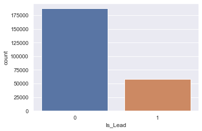

```python
sns.countplot(train_data['Is_Lead'])
plt.show()
```

```python
train_data['Is_Lead'].value_counts(normalize=True)
```

```
0    0.762792
1    0.237208
Name: Is_Lead, dtype: float64
```

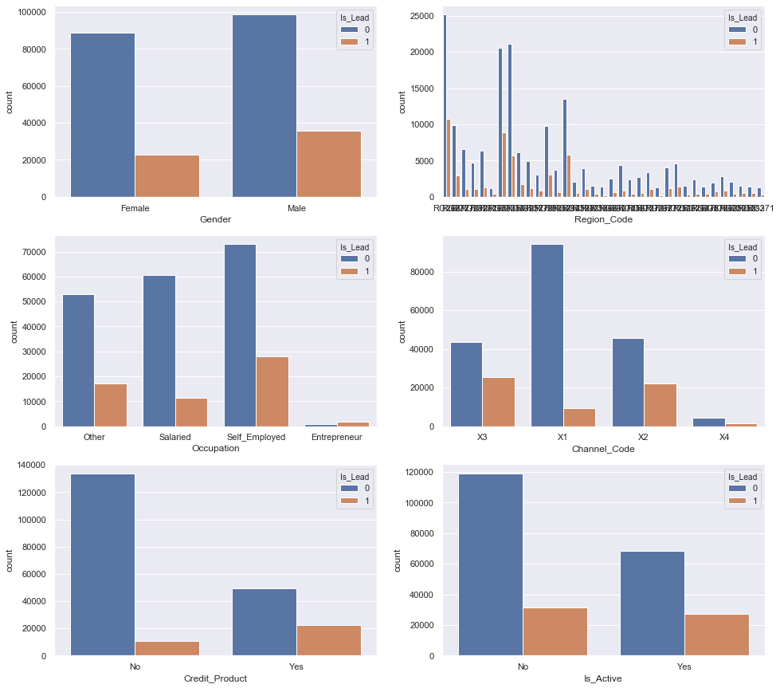

```python
fig,ax = plt.subplots(3,2,figsize=(16,15))
ax = ax.flatten()
for i,col in enumerate(cat_cols):
    sns.countplot(x=col, hue='Is_Lead', data=train_data, ax=ax[i])
```

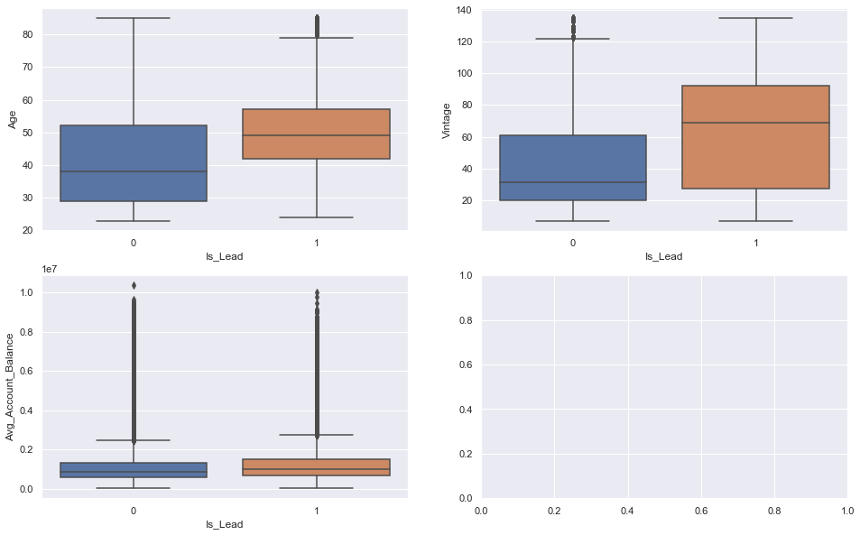

```python
fig,ax = plt.subplots(2,2,figsize=(16,10))
ax=ax.flatten()
for i,col in enumerate(num_cols):
    sns.boxplot(x='Is_Lead', y=col, data=train_data, ax=ax[i])
plt.show()
```

### Missing Values

```python
train_data.isnull().sum()
```

```
Gender                     0
Age                        0
Region_Code                0
Occupation                 0
Channel_Code               0
Vintage                    0
Credit_Product         29325
Avg_Account_Balance        0
Is_Active                  0
Is_Lead                    0
dtype: int64
```

```python
test_data.isnull().sum()
```

```
Gender                     0
Age                        0
Region_Code                0
Occupation                 0
Channel_Code               0
Vintage                    0
Credit_Product         12522
Avg_Account_Balance        0
Is_Active                  0
dtype: int64
```

- Missing Values exist only in the *Credit_Product* column; This is handled later
- First, let's look at each variables independently
- All Categorical variables should be label encoded

### Gender

```python
train_data['Gender'].value_counts()
```

```
Male      134197
Female    111528
Name: Gender, dtype: int64
```

```python
# Label Encoding
gender_encoding = {'Male':0, 'Female':1}
train_data['Gender'].replace(gender_encoding, inplace=True)
test_data['Gender'].replace(gender_encoding, inplace=True)
train_data['Gender'].value_counts()
```

```
0    134197
1    111528
Name: Gender, dtype: int64
```

### Region_Code

```python
train_data['Region_Code'].value_counts().sort_index()
```

```
RG250     2496
RG251     5950
RG252     4286
RG253     1858
RG254    26840
RG255     2018
RG256     2847
RG257     6101
RG258     1951
RG259     2586
RG260     3110
RG261     7633
RG262     1788
RG263     3687
RG264     2793
RG265     1546
RG266     1578
RG267     1497
RG268    35934
RG269     7863
RG270     7720
RG271     1542
RG272     5252
RG273     4497
RG274     5286
RG275     3245
RG276     2764
RG277    12826
RG278     1822
RG279     3976
RG280    12775
RG281     5093
RG282     5829
RG283    29416
RG284    19320
Name: Region_Code, dtype: int64
```

```python
# Label Encoding
rcode_encoding = lambda x: int(x[2:])-249
train_data['Region_Code'] = train_data['Region_Code'].apply(rcode_encoding)
test_data['Region_Code'] = test_data['Region_Code'].apply(rcode_encoding)
train_data['Region_Code'].value_counts().sort_index()
```

```
1      2496
2      5950
3      4286
4      1858
5     26840
6      2018
7      2847
8      6101
9      1951
10     2586
11     3110
12     7633
13     1788
14     3687
15     2793
```

[output cut: 21 more lines]

### Occupation

```python
train_data['Occupation'].value_counts()
```

```
Self_Employed    100886
Salaried          71999
Other             70173
Entrepreneur       2667
Name: Occupation, dtype: int64
```

```python
# Label Encoding
occ_encoding = {'Other':0, 'Self_Employed':1, 'Entrepreneur':2, 'Salaried':3}
train_data['Occupation'].replace(occ_encoding, inplace=True)
test_data['Occupation'].replace(occ_encoding, inplace=True)
train_data['Occupation'].value_counts()
```

```
1    100886
3     71999
0     70173
2      2667
Name: Occupation, dtype: int64
```

### Channel_Code

```python
train_data['Channel_Code'].value_counts()
```

```
X1    103718
X3     68712
X2     67726
X4      5569
Name: Channel_Code, dtype: int64
```

```python
# Label Encoding
ccode_encoding = lambda x: int(x[1:])
train_data['Channel_Code'] = train_data['Channel_Code'].apply(ccode_encoding)
test_data['Channel_Code'] = test_data['Channel_Code'].apply(ccode_encoding)
train_data['Channel_Code'].value_counts().sort_index()
```

```
1    103718
2     67726
3     68712
4      5569
Name: Channel_Code, dtype: int64
```

### Is_Active

```python
train_data['Is_Active'].value_counts()
```

```
No     150290
Yes     95435
Name: Is_Active, dtype: int64
```

```python
# Label Encoding
isactive_encoding = {'No':0, 'Yes':1}
train_data['Is_Active'].replace(isactive_encoding, inplace=True)
test_data['Is_Active'].replace(isactive_encoding, inplace=True)
train_data['Is_Active'].value_counts()
```

```
0    150290
1     95435
Name: Is_Active, dtype: int64
```

- For numerical variables *Age* and *Vintage*, I have tried to do binning but the results were worse so it's better to leave them as numerical variables
- Log Transformation has improved the scores
- Scaling the numerical variables will be done later

### Age

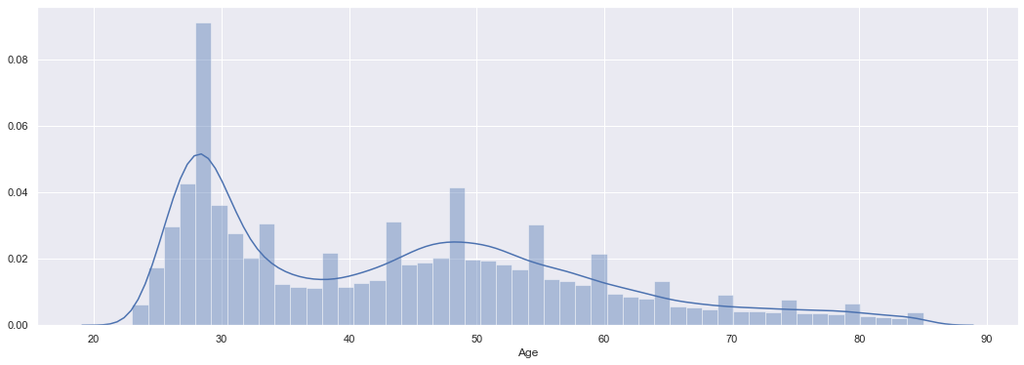

```python
plt.figure(figsize=(18,6))
sns.distplot(train_data['Age'])
plt.show()
```

- Applying Log Transformation to normalize data

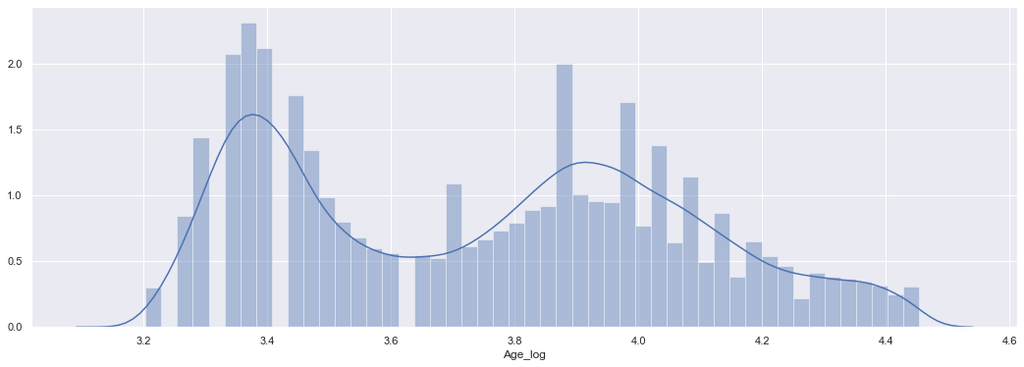

```python
log_transform = lambda x: np.log(x+1)
train_data['Age_log'] = train_data['Age'].apply(log_transform)
test_data['Age_log'] = test_data['Age'].apply(log_transform)

plt.figure(figsize=(18,6))
sns.distplot(train_data['Age_log'])
plt.show()
```

### Vintage

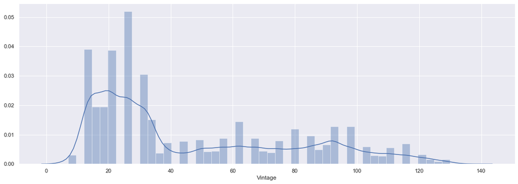

```python
plt.figure(figsize=(18,6))
sns.distplot(train_data['Vintage'])
plt.show()
```

- Applying Log Transformation to normalize data

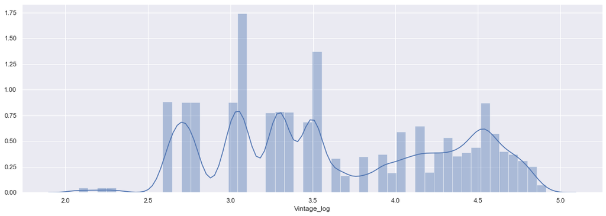

```python
log_transform = lambda x: np.log(x+1)
train_data['Vintage_log'] = train_data['Vintage'].apply(log_transform)
test_data['Vintage_log'] = test_data['Vintage'].apply(log_transform)

plt.figure(figsize=(18,6))
sns.distplot(train_data['Vintage_log'])
plt.show()
```

### Avg_Account_Balance

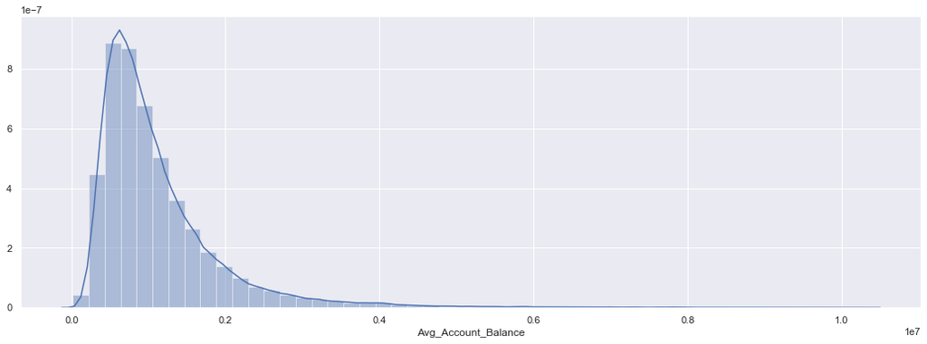

```python
plt.figure(figsize=(18,6))
sns.distplot(train_data['Avg_Account_Balance'])
plt.show()
```

- Applying Log Transformation to normalize data

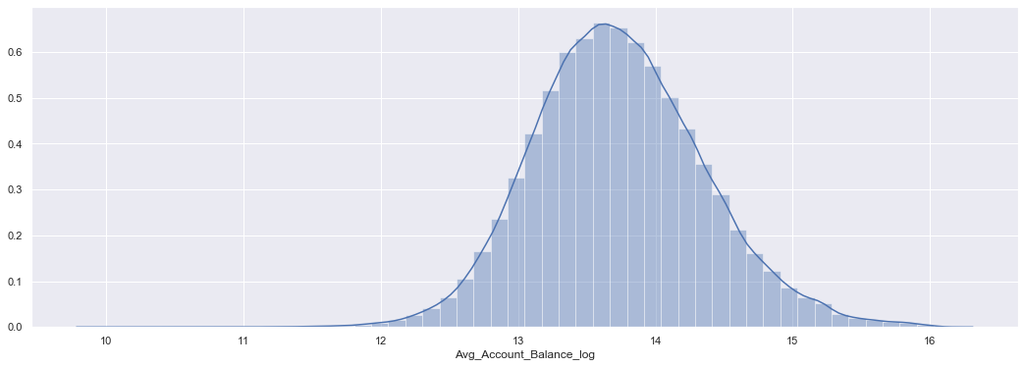

```python
log_transform = lambda x: np.log(x+1)
train_data['Avg_Account_Balance_log'] = train_data['Avg_Account_Balance'].apply(log_transform)
test_data['Avg_Account_Balance_log'] = test_data['Avg_Account_Balance'].apply(log_transform)

plt.figure(figsize=(18,6))
sns.distplot(train_data['Avg_Account_Balance_log'])
plt.show()
```

```python
train_data.drop(columns=['Age','Vintage','Avg_Account_Balance'], inplace=True)
test_data.drop(columns=['Age','Vintage','Avg_Account_Balance'], inplace=True)
```

```python
num_cols = [x+'_log' for x in num_cols]
```

### Credit_Product

```python
train_data['Credit_Product'].fillna('Missing', inplace=True)
test_data['Credit_Product'].fillna('Missing', inplace=True)

train_data['Credit_Product'].value_counts(normalize=True)
```

```
No         0.587474
Yes        0.293185
Missing    0.119341
Name: Credit_Product, dtype: float64
```

- Has >10% Missing values, so these rows cannot be ignored
- Let's look at relationship with other variables independently

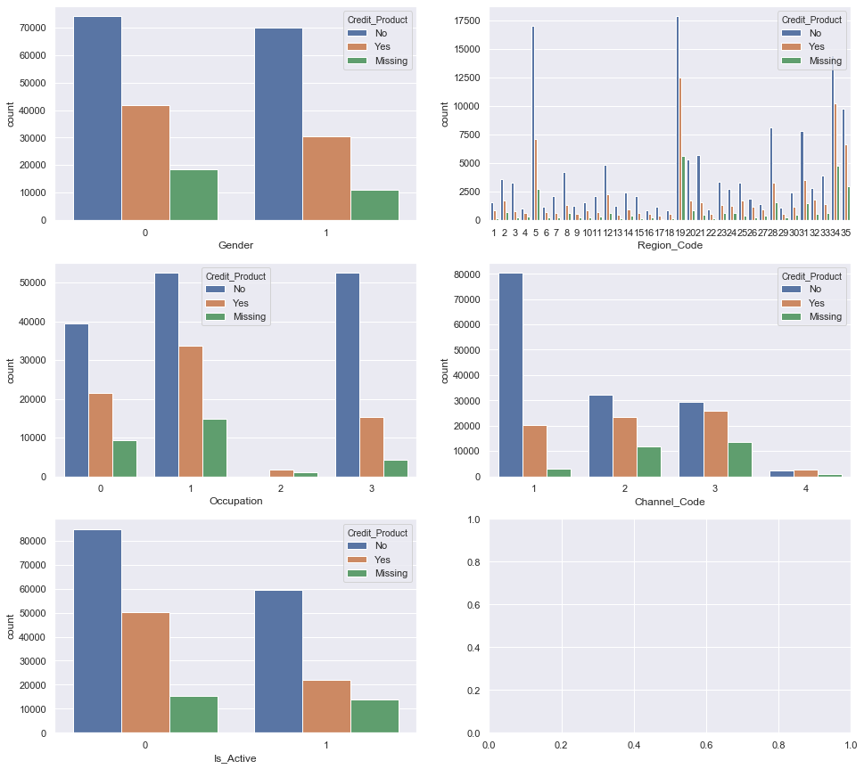

```python
fig,ax = plt.subplots(3,2,figsize=(16,15))
ax = ax.flatten()
for i,col in enumerate([c for c in cat_cols if c != 'Credit_Product']):
    sns.countplot(x=col, hue='Credit_Product', data=train_data, ax=ax[i], hue_order=['No','Yes','Missing'])
```

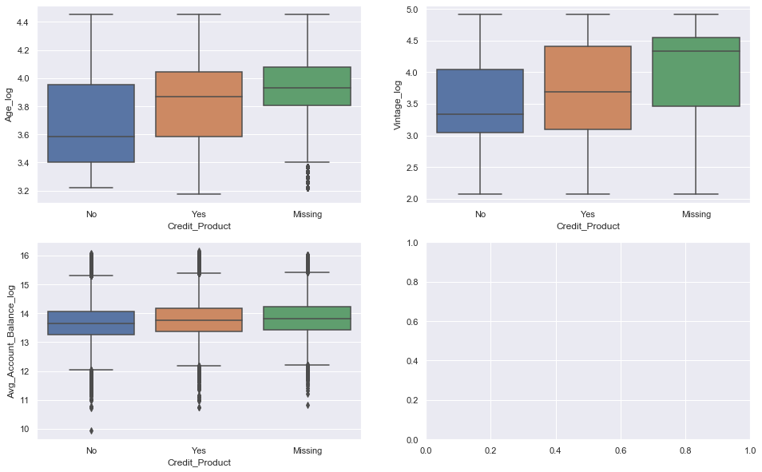

```python
fig,ax = plt.subplots(2,2,figsize=(16,10))
ax=ax.flatten()
for i,col in enumerate(num_cols):
    sns.boxplot(x='Credit_Product', y=col, data=train_data, ax=ax[i], order=['No','Yes','Missing'])
plt.show()
```

- Missing values have an even higher median age and vintage; closer to those with Credit_Product=1
- First, I tried to replace all missing values with 1, which gave good ROC AUC scores
- KNNImputer was attempted but this made ROC AUC scores for all models worse than with previous method
- But, converting all missing values as a new category gave much better results than any other method

#### Imputing Missing Values

```python
# Label Encoding
cp_encoding = {'No':0, 'Yes':2,'Missing':1}
train_data['Credit_Product'].replace(cp_encoding, inplace=True)
test_data['Credit_Product'].replace(cp_encoding, inplace=True)
train_data['Credit_Product'].value_counts(dropna=False, normalize=True)
```

```
0    0.587474
2    0.293185
1    0.119341
Name: Credit_Product, dtype: float64
```

```python
# train_data['Credit_Product'] = train_data['Credit_Product'].fillna(1).astype(int)
# test_data['Credit_Product'] = test_data['Credit_Product'].fillna(1).astype(int)
```

```python
# impute_cols = [x for x in train_data.columns if x not in ['Is_Lead', 'Region_Code', 'Occupation', 'Channel_Code']]
# imputer = KNNImputer()
# train_data[impute_cols] = imputer.fit_transform(train_data[impute_cols])
# test_data[impute_cols] = imputer.transform(test_data[impute_cols])
# train_data['Credit_Product'].value_counts(dropna=False, normalize=True)

# train_data['Credit_Product'] = train_data['Credit_Product'].apply(lambda x : 0 if x==0 else 1)
# test_data['Credit_Product'] = test_data['Credit_Product'].apply(lambda x : 0 if x==0 else 1)
```

```python
train_data['Credit_Product'].value_counts(dropna=False, normalize=True)
```

```
0    0.587474
2    0.293185
1    0.119341
Name: Credit_Product, dtype: float64
```

```python
test_data['Credit_Product'].value_counts(dropna=False, normalize=True)
```

```
0    0.585005
2    0.296092
1    0.118904
Name: Credit_Product, dtype: float64
```

```python
train_data.head()
```

| ID | Gender | Region_Code | Occupation | Channel_Code | Credit_Product | Is_Active | Is_Lead | Age_log | Vintage_log | Avg_Account_Balance_log |
| --- | --- | --- | --- | --- | --- | --- | --- | --- | --- | --- |
| NNVBBKZB | 1 | 19 | 0 | 3 | 0 | 0 | 0 | 4.304065 | 3.784190 | 13.860194 |
| IDD62UNG | 1 | 28 | 3 | 1 | 0 | 0 | 0 | 3.433987 | 3.496508 | 13.274207 |
| HD3DSEMC | 1 | 19 | 1 | 3 | 0 | 1 | 0 | 4.043051 | 3.295837 | 14.210465 |
| BF3NC7KV | 0 | 21 | 3 | 1 | 0 | 0 | 0 | 3.555348 | 2.995732 | 13.061456 |
| TEASRWXV | 1 | 33 | 3 | 1 | 0 | 0 | 0 | 3.433987 | 3.526361 | 13.695361 |

```python
test_data.head()
```

| ID | Gender | Region_Code | Occupation | Channel_Code | Credit_Product | Is_Active | Age_log | Vintage_log | Avg_Account_Balance_log |
| --- | --- | --- | --- | --- | --- | --- | --- | --- | --- |
| VBENBARO | 0 | 5 | 0 | 1 | 2 | 0 | 3.401197 | 3.258097 | 13.517599 |
| CCMEWNKY | 0 | 19 | 0 | 2 | 1 | 0 | 3.784190 | 3.912023 | 13.738130 |
| VK3KGA9M | 0 | 21 | 3 | 1 | 0 | 0 | 3.465736 | 2.708050 | 12.282802 |
| TT8RPZVC | 0 | 23 | 0 | 1 | 0 | 0 | 3.401197 | 3.526361 | 13.674029 |
| SHQZEYTZ | 1 | 21 | 0 | 1 | 0 | 0 | 3.401197 | 2.995732 | 13.395573 |

## Preparing Data for Modelling

```python
x = train_data.drop(columns='Is_Lead')
y = train_data['Is_Lead']
test = test_data
```

```python
cat_cols = [c for c in x.columns if c not in num_cols]
cat_cols
```

```
['Gender',
 'Region_Code',
 'Occupation',
 'Channel_Code',
 'Credit_Product',
 'Is_Active']
```

- Feature selection using sklearn.feature_selection.RFE (Recursive Feature Elimnation) was attempted and it selected 5 features but this drastically reduced the ROC AUC Scores

### Train Test Split

```python
xtrain,xtest,ytrain,ytest = train_test_split(x,y,test_size=0.2,random_state=1)
```

### Scaling

- Standard scaling gave better results than MinMax scaling

```python
sc = StandardScaler()
xtrain[num_cols] = sc.fit_transform(xtrain[num_cols])
xtest[num_cols] = sc.transform(xtest[num_cols])
test[num_cols] = sc.transform(test[num_cols])
```

## Classification - Modelling and Evaluation

```python
# function to calculate ROC AUC score and plot the roc curve
def evaluate_roc(model, name, display=True):
    yprob = model.predict_proba(xtest)[:,1]
    roc_auc = metrics.roc_auc_score(ytest,yprob)

    if display:
        print('ROC AUC =', roc_auc)

        # ROC curve
        fpr,tpr,threshold = metrics.roc_curve(ytest,yprob)
        lw = 2
        plt.plot(fpr,tpr,color='darkorange',lw=lw,label='ROC Curve (area = %0.2f)'%roc_auc)
        plt.plot([0,1],[0,1],color='navy',lw=lw,linestyle='--')
        plt.xlim([0.0, 1.0])
        plt.ylim([0.0, 1.05])
        plt.xlabel('FPR')
        plt.ylabel('TPR')
        plt.title('ROC Curve')
        plt.legend(loc='lower right')
        plt.show()

    return {'name':name, 'roc_auc':roc_auc,
           'roc_curve': {'fpr':fpr, 'tpr':tpr, 'threhsold':threshold}}
```

```python
# function to generate prediction probabilities for test data
def predict_and_export(model, name):
    test_prob = model.predict_proba(test)[:,1]
    df = pd.DataFrame({'ID':test.index,'Is_Lead':test_prob})

    filename = 'submissions/submission-' + name + '.csv'
    df.to_csv(filename,index=False)
```

Applying different Classification algorithms:

### Logistic Regression

```
ROC AUC = 0.772706787937633
```

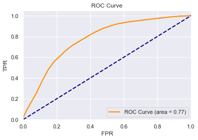

```python
logreg = LogisticRegression()
logreg.fit(xtrain, ytrain)
logreg_roc = evaluate_roc(logreg, 'Logistic Regression')
```

```python
predict_and_export(logreg, 'logreg')
```

### Random Forest

```
ROC AUC = 0.8539690932196483
```

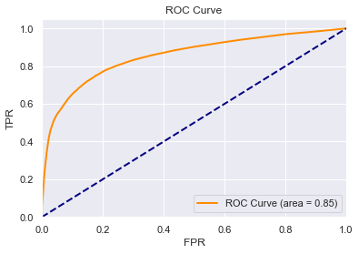

```python
rf = RandomForestClassifier()
rf.fit(xtrain, ytrain)
rf_roc = evaluate_roc(rf, 'Random Forest')
```

```python
predict_and_export(rf, 'rforest')
```

### Gradient Boosting

```
ROC AUC = 0.8715719633540114
```

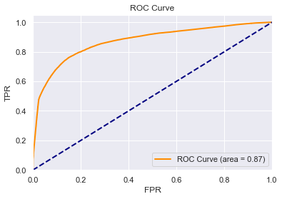

```python
gb = GradientBoostingClassifier()
gb.fit(xtrain, ytrain)
gb_roc = evaluate_roc(gb, 'Gradient Boost')
```

```python
predict_and_export(gb, 'gboost')
```

### XGBoost

```
ROC AUC = 0.8704913247250208
```

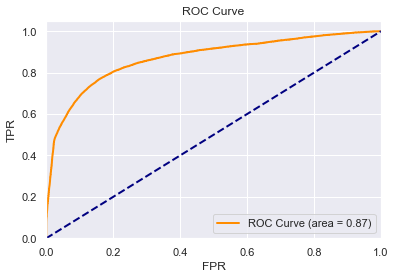

```python
xgb = XGBClassifier(objective='binary:logistic', use_label_encoder=False)
xgb.fit(xtrain, ytrain, eval_metric='auc')
xgb_roc = evaluate_roc(xgb, 'XGBoost')
```

```python
predict_and_export(xgb, 'xgboost')
```

### LightGBM

```
ROC AUC = 0.8726445999253634
```

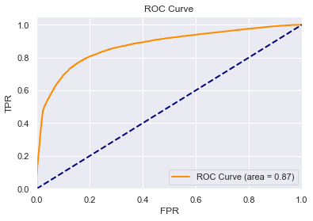

```python
lgbm = LGBMClassifier()
lgbm.fit(xtrain, ytrain)
lgbm_roc = evaluate_roc(lgbm, 'LGBM')
```

```python
predict_and_export(lgbm, 'lgbm')
```

```python
pd.DataFrame({'Feature':xtrain.columns,
              'Importance':lgbm.feature_importances_}).sort_values(by='Importance', ascending=False)
```

|  | Feature | Importance |
| --- | --- | --- |
| 6 | Age_log | 686 |
| 7 | Vintage_log | 569 |
| 8 | Avg_Account_Balance_log | 526 |
| 2 | Occupation | 378 |
| 1 | Region_Code | 350 |
| 3 | Channel_Code | 151 |
| 4 | Credit_Product | 147 |
| 5 | Is_Active | 128 |
| 0 | Gender | 65 |

## CatBoost

```
ROC AUC = 0.8710404703978629
```

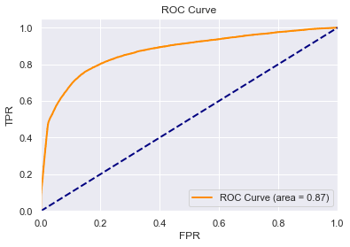

```python
cb = CatBoostClassifier(verbose=False)
cb.fit(xtrain, ytrain)
cb_roc = evaluate_roc(cb, 'CatBoost')
```

```python
predict_and_export(cb, 'cb')
```

## Compare Models

- Plotting all the ROC courves on one graph to compare them

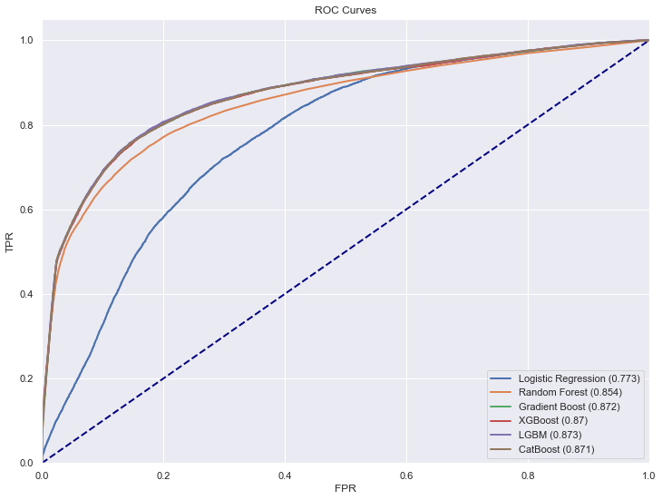

```python
model_rocs = [logreg_roc, rf_roc, gb_roc, xgb_roc, lgbm_roc, cb_roc]

fig = plt.figure(figsize=(12,9))
lw = 2
plt.plot([0,1],[0,1],color='navy',lw=lw,linestyle='--')
plt.xlim([0.0, 1.0])
plt.ylim([0.0, 1.05])
plt.xlabel('FPR')
plt.ylabel('TPR')
plt.title('ROC Curves')

for x in model_rocs:
    roc_label = x['name'] + ' (' + str(round(x['roc_auc'], 3)) + ')'
    plt.plot(x['roc_curve']['fpr'], x['roc_curve']['tpr'], lw=lw, label=roc_label)

plt.legend(loc='lower right')
plt.show()
```

- LGBMClassifier gave the best ROC AUC score